# Logistic regression (+probit): Drinking prediction

by JUMEX365

## Packages

```r
library(sjPlot)
library(foreign)
library(dplyr)
library(DescTools)
library(pscl)
library(base)
library(ggplot2)
library(psych)
```

## Data + editing

```r
data321 = read.spss("HBSC 2014 5 countries.sav", to.data.frame=TRUE)

data321$drink33 <- ifelse(data321$alcltm == "Never", 0, 1)
data321$aggress33 <- ifelse(data321$beenbullied == "Haven't", 0, 1)

findata <- data321[c("drink33", "aggress33", "m96", "friendhelp", "friendshare", "friendtalk", "sex", "AGE")]
findata$friendhelp <- as.numeric(findata$friendhelp)
findata$friendshare <- as.numeric(findata$friendshare)
findata$friendtalk <- as.numeric(findata$friendtalk)
findata$AGE <- round(findata$AGE)
findata <- na.omit(findata)
```

# Part1

## Descriptive statistics

Creating function for defining mode

```r
function.mode <- function(x) {
  theonly <- na.omit(unique(x))
  theonly[which.max(tabulate(match(x, theonly,  nomatch = NA_integer_, incomparables = NULL)))]
}
```

## drink33: Dependent variable: drinking behavior of adolesent

```r
describe(findata$drink33)
```

```
##    vars     n mean  sd median trimmed mad min max range skew kurtosis se
## X1    1 21910 0.43 0.5      0    0.42   0   0   1     1 0.26    -1.93  0
```

```r
function.mode(findata$drink33)
```

```
## [1] 0
```

Mean: 0,43

Median: 0

Mode: 0

Distribution is shown on graph

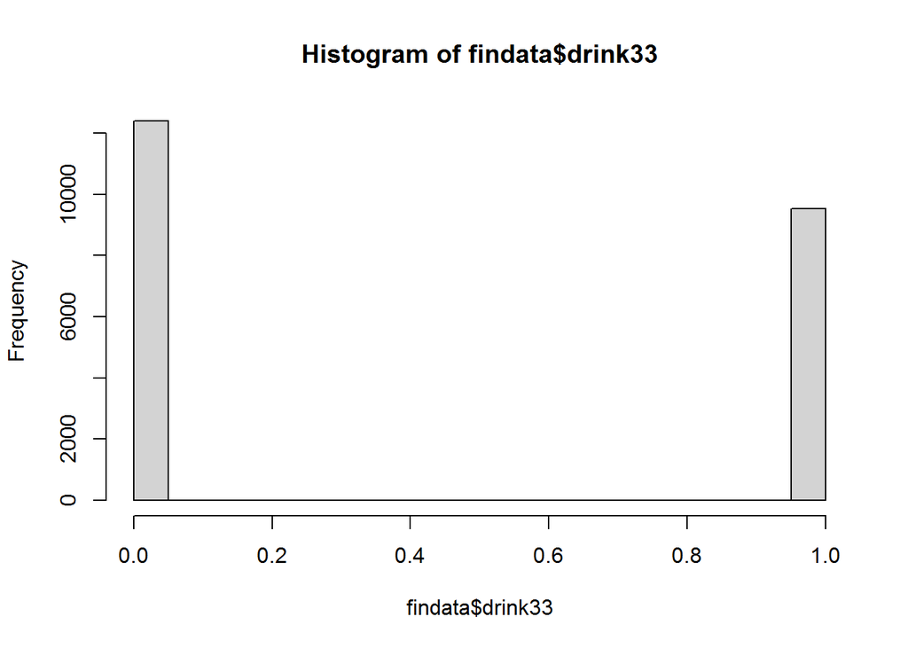

```r
hist(findata$drink33)
```

## Independent variables:

## M96 (meet friends after school after 20.00)

Distribution is shown on graph.

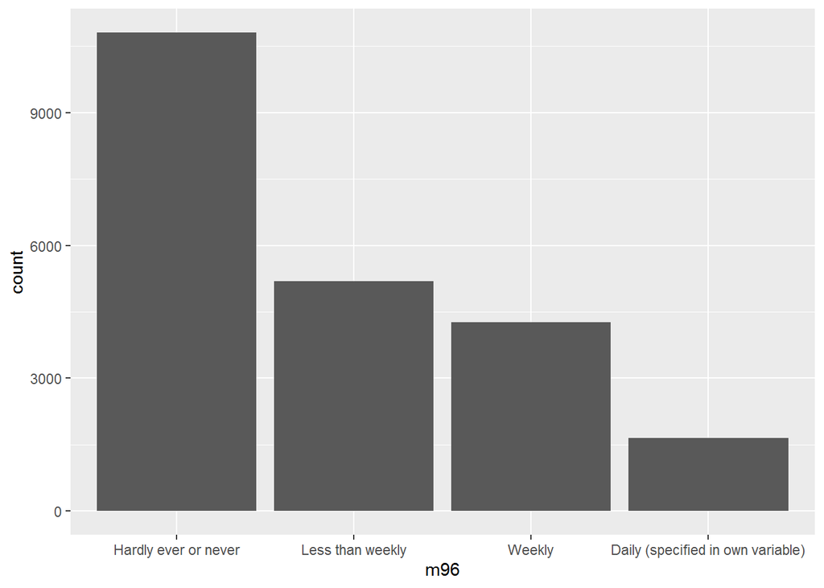

```r
ggplot(findata, aes(x = m96))+geom_bar()
```

## friendhelp

```r
describe(findata$friendhelp)
```

```
##    vars     n mean   sd median trimmed  mad min max range  skew kurtosis   se
## X1    1 21910 5.33 1.69      6    5.58 1.48   1   7     6 -1.01     0.25 0.01
```

```r
function.mode(findata$friendhelp)
```

```
## [1] 7
```

Mean: 5.33

Median: 6

Mode: 7

Distribution is shown on graph

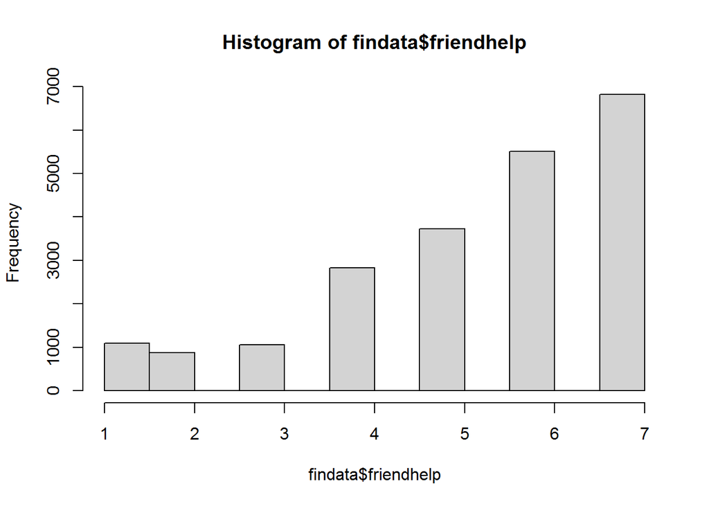

```r
hist(findata$friendhelp)
```

## friendtalk

```r
describe(findata$friendtalk)
```

```
##    vars     n mean   sd median trimmed  mad min max range  skew kurtosis   se
## X1    1 21910 5.43 1.87      6    5.75 1.48   1   7     6 -1.13     0.16 0.01
```

```r
function.mode(findata$friendtalk)
```

```
## [1] 7
```

Mean: 5.43

Median: 6

Mode: 7

Distribution is shown on graph

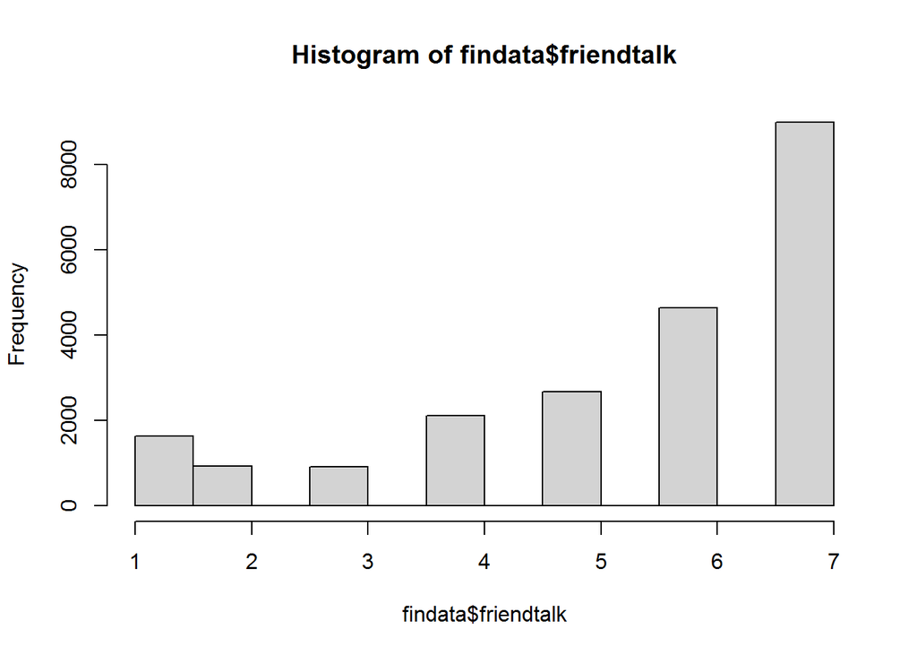

```r
hist(findata$friendtalk)
```

## Control variables:

## sex

Distribution is shown on graph

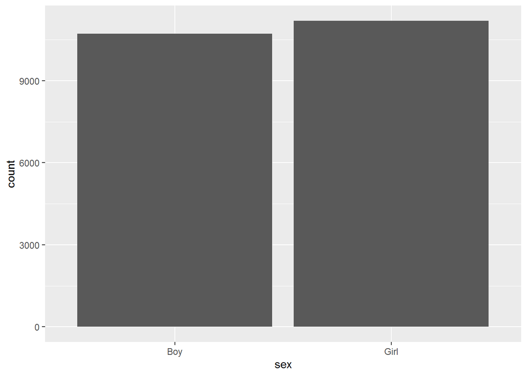

```r
ggplot(findata, aes(x = sex))+geom_bar()
```

## AGE

```r
describe(findata$AGE)
```

```
##    vars     n  mean   sd median trimmed  mad min max range  skew kurtosis   se
## X1    1 21910 13.74 1.67     14    13.8 1.48  10  16     6 -0.22    -1.11 0.01
```

```r
function.mode(findata$AGE)
```

```
## [1] 16
```

Mean: 13.74

Median: 14

Mode: 16

Distribution is shown on graph

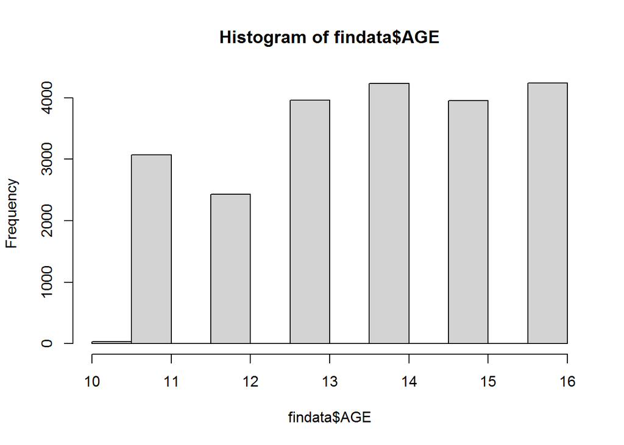

```r
hist(findata$AGE)
```

## Visualization of variables relationship.

## drink33 and m96

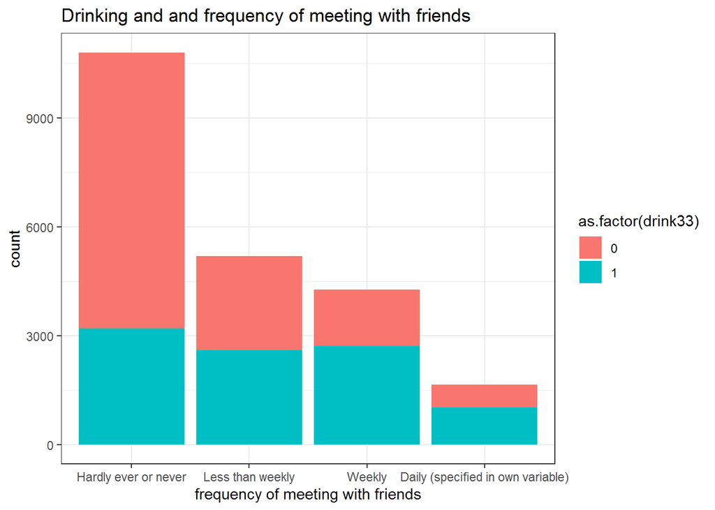

```r
ggplot(findata, aes(x = m96))+geom_bar(aes(fill = as.factor(drink33)))+theme_bw()+
  xlab("frequency of meeting with friends")+
  ggtitle("Drinking and and frequency of meeting with friends")
```

## drink33 and friendtalk

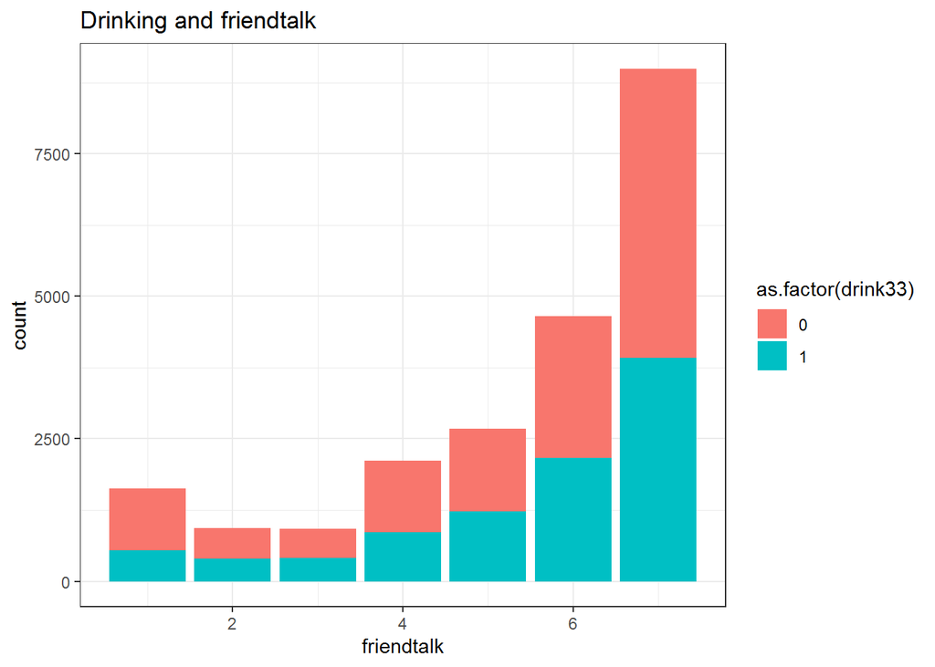

```r
ggplot(findata, aes(x = friendtalk))+geom_bar(aes(fill = as.factor(drink33)))+theme_bw()+
  xlab("friendtalk")+
  ggtitle("Drinking and friendtalk")
```

## drink33 and friendhelp

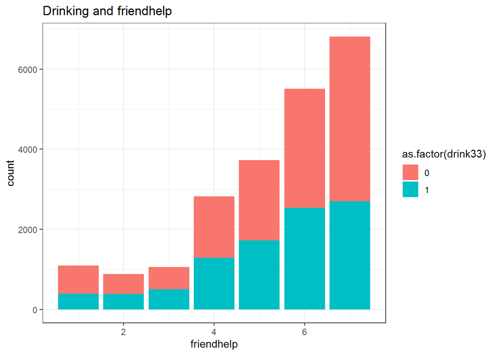

```r
ggplot(findata, aes(x = friendhelp))+geom_bar(aes(fill = as.factor(drink33)))+theme_bw()+
  xlab("friendhelp")+
  ggtitle("Drinking and friendhelp")
```

## drink33 and AGE

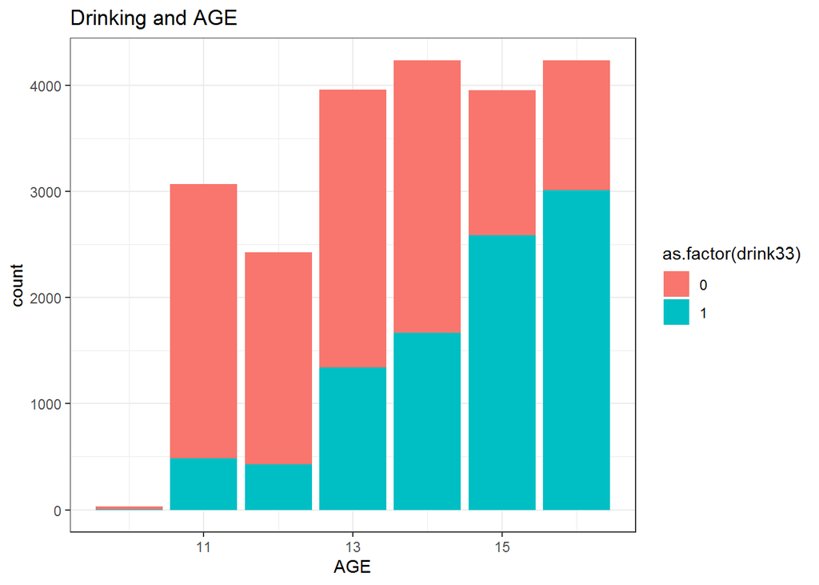

```r
ggplot(findata, aes(x = AGE))+geom_bar(aes(fill = as.factor(drink33)))+theme_bw()+
  xlab("AGE")+
  ggtitle("Drinking and AGE")
```

## drink33 and sex

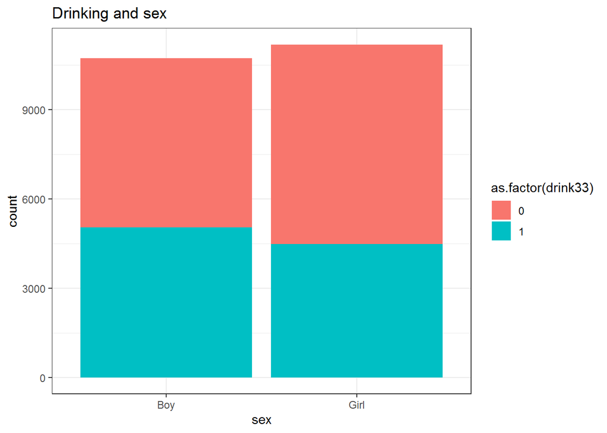

```r
ggplot(findata, aes(x = sex))+geom_bar(aes(fill = as.factor(drink33)))+theme_bw()+
  xlab("sex")+
  ggtitle("Drinking and sex")
```

## Model (drinking logit)

```r
mod77 <- glm(as.factor(drink33) ~ friendhelp + friendtalk + m96 + sex + AGE,
             family = binomial(link = logit), findata)

summary(mod77)
```

```
##
## Call:
## glm(formula = as.factor(drink33) ~ friendhelp + friendtalk +
##     m96 + sex + AGE, family = binomial(link = logit), data = findata)
##
## Deviance Residuals:
##     Min       1Q   Median       3Q      Max
## -1.9986  -0.8963  -0.5051   0.9494   2.3527
##
## Coefficients:
##                                      Estimate Std. Error z value Pr(>|z|)
## (Intercept)                          -7.65284    0.15179 -50.416  < 2e-16 ***
## friendhelp                           -0.04755    0.01224  -3.884 0.000103 ***
## friendtalk                            0.05245    0.01122   4.675 2.95e-06 ***
## m96Less than weekly                   0.54213    0.03774  14.367  < 2e-16 ***
## m96Weekly                             0.98303    0.04149  23.691  < 2e-16 ***
## m96Daily (specified in own variable)  0.98805    0.05962  16.571  < 2e-16 ***
## sexGirl                              -0.30515    0.03126  -9.762  < 2e-16 ***
## AGE                                   0.51260    0.01032  49.675  < 2e-16 ***
## ---
## Signif. codes:  0 '***' 0.001 '**' 0.01 '*' 0.05 '.' 0.1 ' ' 1
##
## (Dispersion parameter for binomial family taken to be 1)
##
##     Null deviance: 29997  on 21909  degrees of freedom
## Residual deviance: 25145  on 21902  degrees of freedom
## AIC: 25161
##
## Number of Fisher Scoring iterations: 3
```

First of all, it is important to mention that all variables are significant.

Each extra point of friendhelp variable decrease logarithm of odds ratio of drinking by -0.05.

Each increase of friendtalk variable increase logarithm of odds ratio of drinking by 0.05.

If person meets with friends less than weekly, it increase logarithm of odds ratio of drinking by 0.54.

If person meets with friends weekly, it leads to growth of logarithm of odds ratio of drinking by 0.98.

For girls, the logarithm of odds ratio of drinking decreases by -0.31.

Each extra point of age increase logarithm of odds ratio of drinking by 0.51.

```r
exp(coef(mod77))
```

```
##                          (Intercept)                           friendhelp
##                          0.000474694                          0.953564187
##                           friendtalk                  m96Less than weekly
##                          1.053848107                          1.719665237
##                            m96Weekly m96Daily (specified in own variable)
##                          2.672528779                          2.685994044
##                              sexGirl                                  AGE
##                          0.737015777                          1.669622788
```

Each extra point of friendhelp variable decrease odds ratio of drinking by almost 5%

Each increase of friendtalk variable increase odds ratio of drinking by 5%.

If person meets with friends less than weekly, it increase odds ratio of drinking by 72%.

If person meets with friends weekly, it leads to growth of odds ratio of drinking by 165%.

For girls, odds ratio of drinking decreases by 26%.

Each extra point of age increase odds ratio of drinking by 67%.

# Model fit.

```r
library(DescTools)
PseudoR2(mod77)
```

```
##  McFadden
## 0.1617599
```

Pseudo r (mcfadden) is high (0.161>0.1). So model fits data well.

```r
library(pscl)
hitmiss(mod77)
```

```
## Classification Threshold = 0.5
##         y=0  y=1
## yhat=0 9268 3363
## yhat=1 3121 6158
## Percent Correctly Predicted = 70.41%
## Percent Correctly Predicted = 74.81%, for y = 0
## Percent Correctly Predicted = 64.68%  for y = 1
## Null Model Correctly Predicts 56.54%
```

```
## [1] 70.40621 74.80830 64.67808
```

Null model predicts = 57% of data.

Model correctly predicts 70% of data, that is quite good.

It predicts better absence of alcohol consumption than drinking.

# Part 2

## aggress33: Dependent variable: bulling behaviour

```r
describe(findata$aggress33)
```

```
##    vars     n mean   sd median trimmed mad min max range skew kurtosis se
## X1    1 21910 0.28 0.45      0    0.22   0   0   1     1 0.99    -1.02  0
```

```r
function.mode(findata$aggress33)
```

```
## [1] 0
```

Mean: 0.28

Median: 0

Mode: 0

Distribution is shown on graph

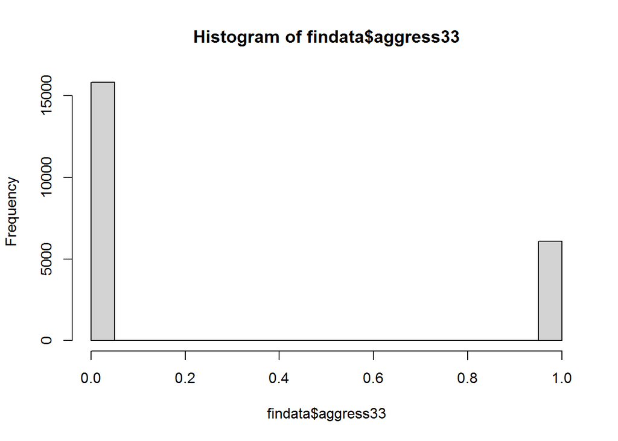

```r
hist(findata$aggress33)
```

## Independent variables:

## M96 (meet friends after school after 20.00) (the same)

Distribution is shown on graph

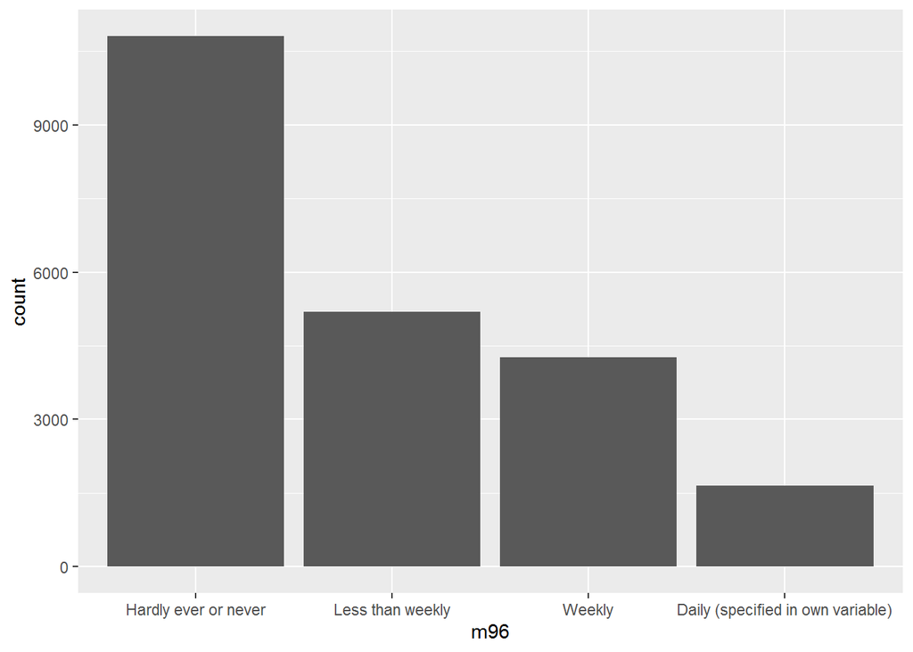

```r
ggplot(findata, aes(x = m96))+geom_bar()
```

## friendhelp (the same)

```r
describe(findata$friendhelp)
```

```
##    vars     n mean   sd median trimmed  mad min max range  skew kurtosis   se
## X1    1 21910 5.33 1.69      6    5.58 1.48   1   7     6 -1.01     0.25 0.01
```

```r
function.mode(findata$friendhelp)
```

```
## [1] 7
```

Mean: 5.33

Median: 6

Mode: 7

Distribution is shown on graph

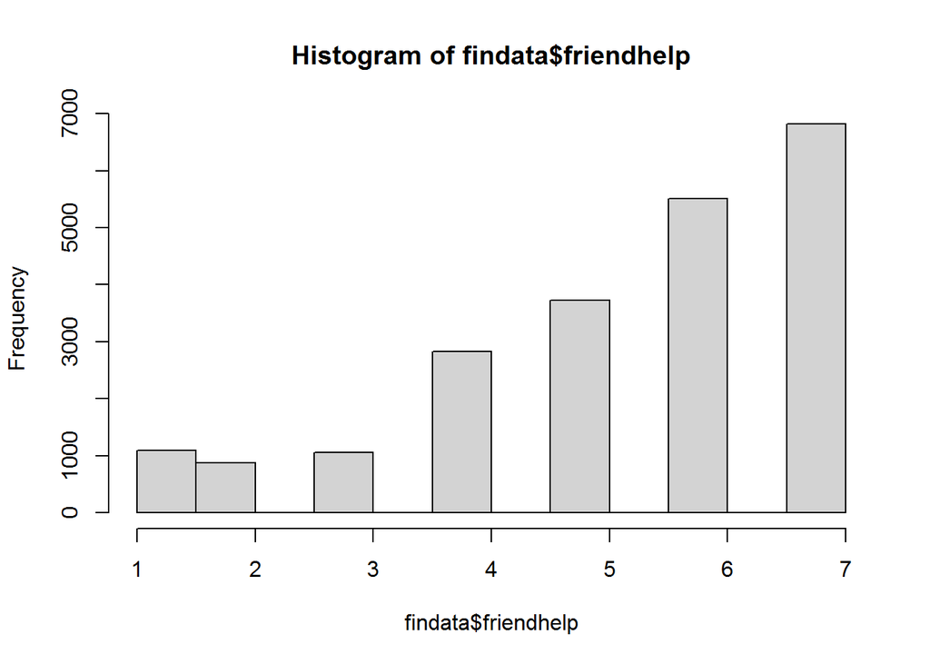

```r
hist(findata$friendhelp)
```

## friendshare (new)

```r
describe(findata$friendshare)
```

```
##    vars     n mean  sd median trimmed  mad min max range  skew kurtosis   se
## X1    1 21910 5.74 1.7      6    6.09 1.48   1   7     6 -1.47     1.27 0.01
```

```r
function.mode(findata$friendshare)
```

```
## [1] 7
```

Mean: 5.74

Median: 6

Mode: 7

Distribution is shown on graph

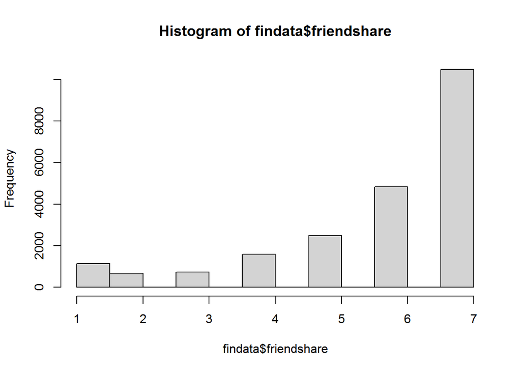

```r
hist(findata$friendshare)
```

## Control variables:

## sex (the same)

Distribution is shown on graph

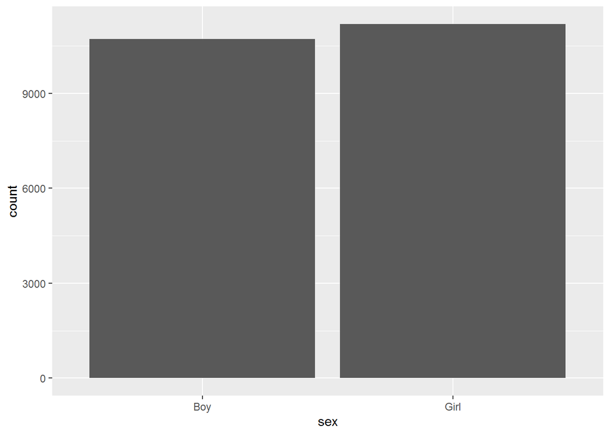

```r
ggplot(findata, aes(x = sex))+geom_bar()
```

## AGE (the same)

```r
describe(findata$AGE)
```

```
##    vars     n  mean   sd median trimmed  mad min max range  skew kurtosis   se
## X1    1 21910 13.74 1.67     14    13.8 1.48  10  16     6 -0.22    -1.11 0.01
```

```r
function.mode(findata$AGE)
```

```
## [1] 16
```

Mean: 13.74

Median: 14

Mode: 16

Distribution is shown on graph

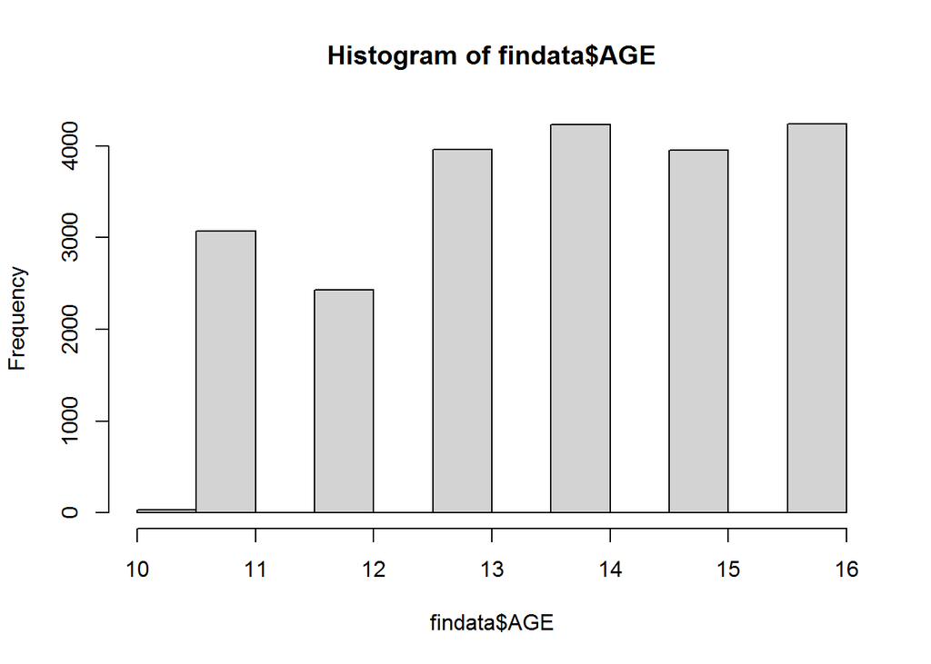

```r
hist(findata$AGE)
```

## Visualization of variables relationship

## aggress33 and m96

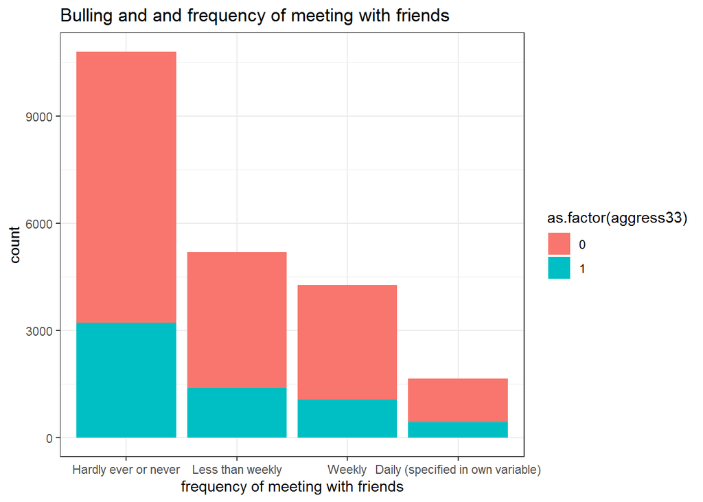

```r
ggplot(findata, aes(x = m96))+geom_bar(aes(fill = as.factor(aggress33)))+theme_bw()+
  xlab("frequency of meeting with friends")+
  ggtitle("Bulling and and frequency of meeting with friends")
```

## aggress33 and friendshare

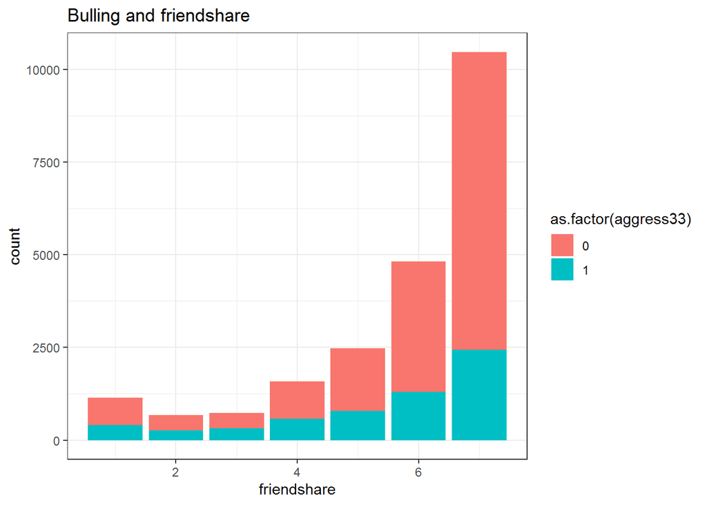

```r
ggplot(findata, aes(x = friendshare))+geom_bar(aes(fill = as.factor(aggress33)))+theme_bw()+
  xlab("friendshare")+
  ggtitle("Bulling and friendshare")
```

## aggress33 and friendhelp

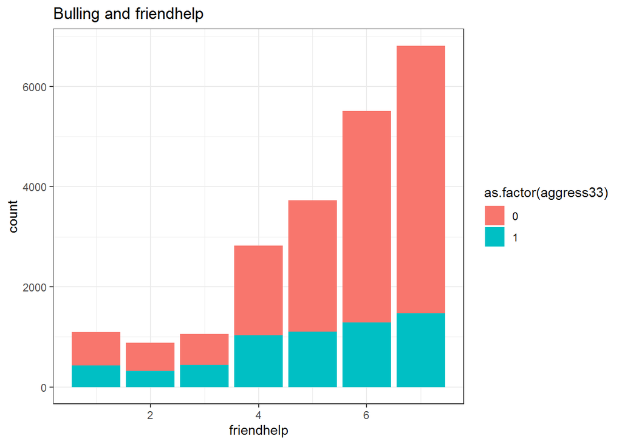

```r
ggplot(findata, aes(x = friendhelp))+geom_bar(aes(fill = as.factor(aggress33)))+theme_bw()+
  xlab("friendhelp")+
  ggtitle("Bulling and friendhelp")
```

## aggress33 and AGE

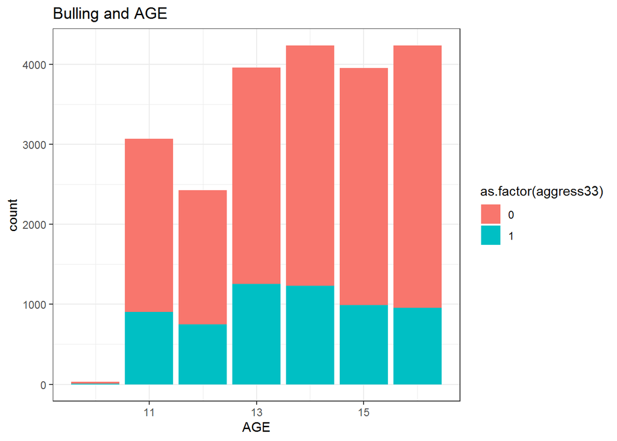

```r
ggplot(findata, aes(x = AGE))+geom_bar(aes(fill = as.factor(aggress33)))+theme_bw()+
  xlab("AGE")+
  ggtitle("Bulling and AGE")
```

## aggress33 and sex

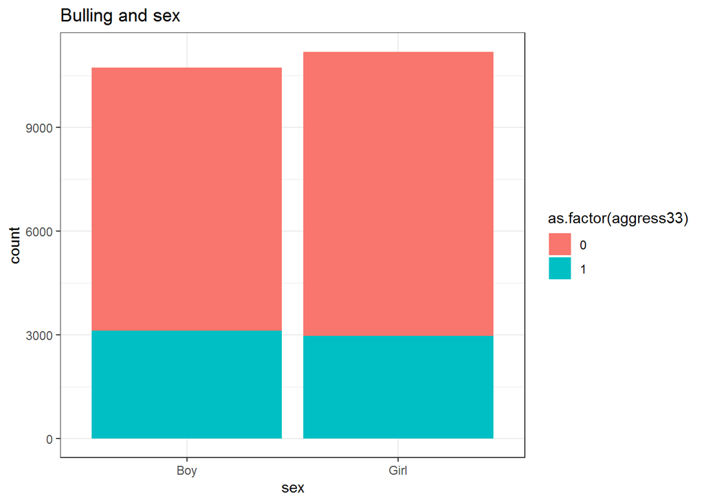

```r
ggplot(findata, aes(x = sex))+geom_bar(aes(fill = as.factor(aggress33)))+theme_bw()+
  xlab("sex")+
  ggtitle("Bulling and sex")
```

## Model (bulling probit)

```r
mod99 <- glm(as.factor(aggress33) ~ friendhelp + friendshare + m96 + sex + AGE,
             family = binomial(link = probit), findata)

summary(mod99)
```

```
##
## Call:
## glm(formula = as.factor(aggress33) ~ friendhelp + friendshare +
##     m96 + sex + AGE, family = binomial(link = probit), data = findata)
##
## Deviance Residuals:
##     Min       1Q   Median       3Q      Max
## -1.2297  -0.8081  -0.7266   1.3353   1.8747
##
## Coefficients:
##                                       Estimate Std. Error z value Pr(>|z|)
## (Intercept)                           0.701567   0.083359   8.416  < 2e-16 ***
## friendhelp                           -0.090665   0.007114 -12.745  < 2e-16 ***
## friendshare                          -0.025305   0.007054  -3.587 0.000334 ***
## m96Less than weekly                  -0.042315   0.023305  -1.816 0.069413 .
## m96Weekly                            -0.073176   0.025633  -2.855 0.004307 **
## m96Daily (specified in own variable) -0.042995   0.036553  -1.176 0.239506
## sexGirl                              -0.020389   0.018606  -1.096 0.273155
## AGE                                  -0.046283   0.005707  -8.110 5.07e-16 ***
## ---
## Signif. codes:  0 '***' 0.001 '**' 0.01 '*' 0.05 '.' 0.1 ' ' 1
##
## (Dispersion parameter for binomial family taken to be 1)
##
##     Null deviance: 25906  on 21909  degrees of freedom
## Residual deviance: 25362  on 21902  degrees of freedom
## AIC: 25378
##
## Number of Fisher Scoring iterations: 4
```

Each extra point of friendhelp variable decrease logarithm of odds ratio of bulling by -0.09.

Each increase of friendshare variable decline logarithm of odds ratio of bulling by -0.03.

If person meets with friends less than weekly, it decrease logarithm of odds ratio of bulling by -0.04.

If person meets with friends weekly, it decline logarithm of odds ratio of bulling by -0.07.

Each extra point of age decrease logarithm of odds ratio of bulling by -0.05.

```r
exp(coef(mod99))
```

```
##                          (Intercept)                           friendhelp
##                            2.0169108                            0.9133239
##                          friendshare                  m96Less than weekly
##                            0.9750128                            0.9585674
##                            m96Weekly m96Daily (specified in own variable)
##                            0.9294377                            0.9579166
##                              sexGirl                                  AGE
##                            0.9798179                            0.9547716
```

Each extra point of friendhelp variable decrease odds ratio of bulling by ~9%.

Each increase of friendshare variable decline odds ratio of bulling by ~3%.

If person meets with friends less than weekly, it decrease odds ratio of bulling by ~4%.

If person meets with friends weekly, it decline odds ratio of bulling by ~7%.

Each extra point of age decrease odds ratio of bulling by ~5%.

## Model fit.

```r
PseudoR2(mod99)
```

```
##   McFadden
## 0.02098335
```

Pseudo r (mcfadden) is Low (0.02<0.1). So model fits data badly.

```r
hitmiss(mod99)
```

```
## Classification Threshold = 0.5
##          y=0  y=1
## yhat=0 15702 6012
## yhat=1   114   82
## Percent Correctly Predicted = 72.04%
## Percent Correctly Predicted = 99.28%, for y = 0
## Percent Correctly Predicted = 1.346%  for y = 1
## Null Model Correctly Predicts 72.19%
```

```
## [1] 72.040164 99.279211  1.345586
```

Null model predicts = 72% of data.

Model correctly predicts 72% of data, that is not bad.

But predicts better absence of bulling well, but almost do not predict pretense of it.